# Logistic Regression

2023-10-30

## Prerequisites

We’ll load basic libraries, while calling explicitly functions from other modules to reinforce where functions come from.

```r
library(tidyverse)
```

We’ll use the employee attrition dataset.

```r
data(attrition, package = "modeldata")

df <- attrition %>%
    as_tibble() %>%
    mutate(
        across(
            where(is.ordered),
            factor,
            ordered = FALSE))

set.seed(123)

churn_split <- rsample::initial_split(
    df,
    prop = .7,
    strata = "Attrition")

churn_train <- rsample::training(churn_split)
churn_test <- rsample::testing(churn_split)
```

## Why logistic regression

Logistic regression is a variation over linear regression for cases where the predicted variable has some additional restrictions, such as being a probability between 0 and 1. More information can be found in [Logistic regression](https://en.wikipedia.org/wiki/Logistic_regression).

## Simple logistic regression

We will use `glm` (generalized linear models, more information can be found in [Generalized linear model](https://en.wikipedia.org/wiki/Generalized_linear_model)). We will fit two models to predict the `Attrition` variable. The first one will consider as a predictor the montly income of employees (`MonthlyIncome`) and the second one will consider whethe or not the employee works overtime (`OverTime`). The book uses `glm` directly, but in this case we will use `tidymodels`.

```r
form_1 <- Attrition ~ MonthlyIncome
form_2 <- Attrition ~ OverTime

model_base <- parsnip::logistic_reg() %>%
    parsnip::set_engine("glm") %>%
    parsnip::set_mode("classification")

wf_1 <- workflows::workflow() %>%
    workflows::add_formula(form_1) %>%
    workflows::add_model(model_base) %>%
    parsnip::fit(
        data = churn_train)

wf_2 <- workflows::workflow() %>%
    workflows::add_formula(form_2) %>%
    workflows::add_model(model_base) %>%
    parsnip::fit(
        data = churn_train)
```

If we wanted to see the predicted probabilities:

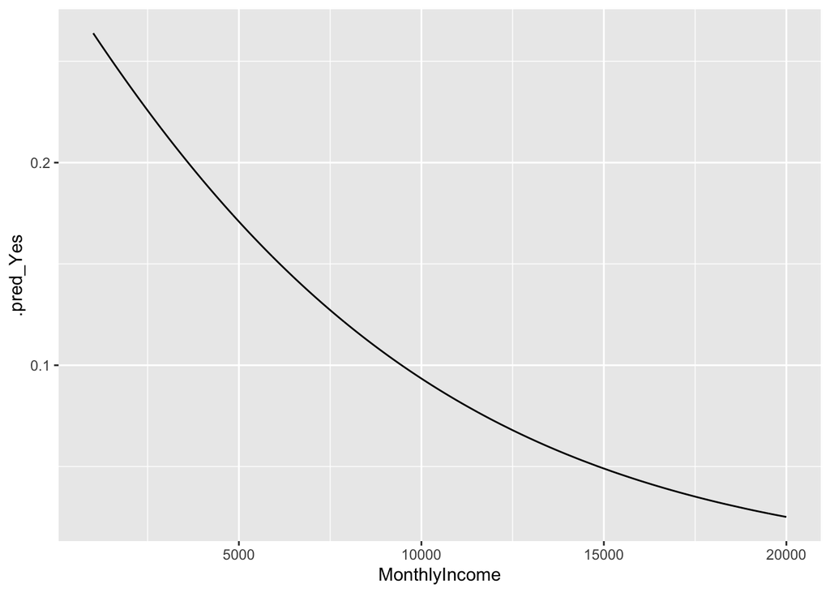

```r
wf_1 %>%
    broom::augment(
        churn_train) %>%
    ggplot(
        aes(MonthlyIncome, .pred_Yes)) +
    geom_line()
```

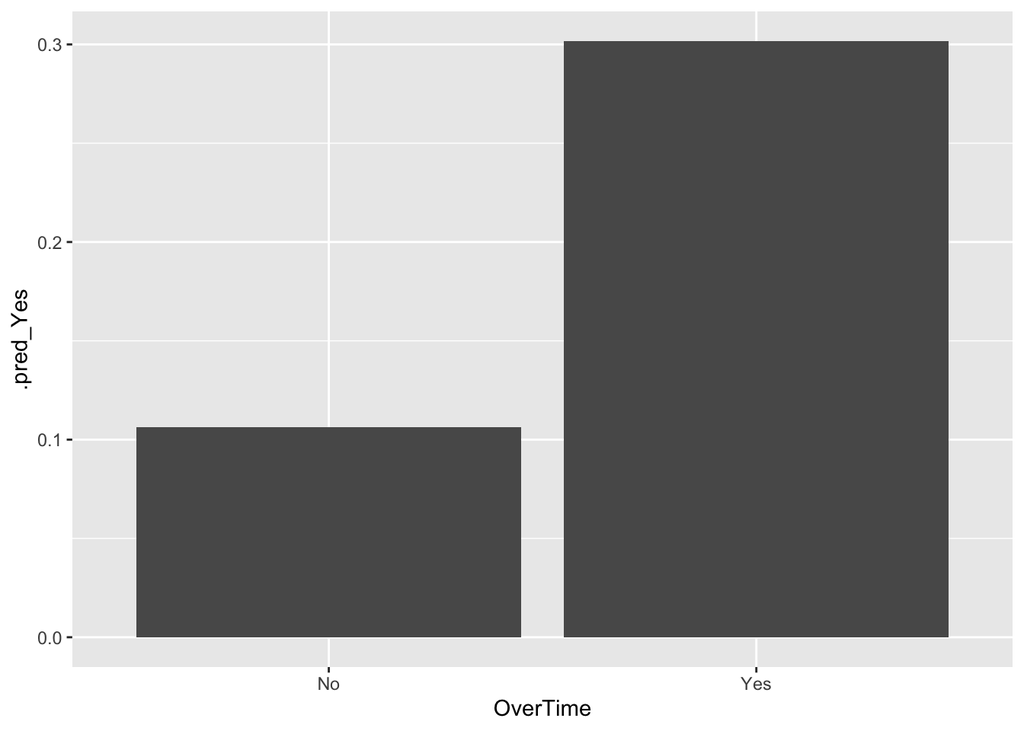

```r
wf_2 %>%
    broom::augment(
        churn_train) %>%
    distinct(
        OverTime,
        .pred_Yes) %>%
    ggplot(
        aes(OverTime, .pred_Yes)) +
    geom_col()
```

The estimated coefficients can be retrieved with `broom::tidy`.

```r
wf_1 %>%
    broom::tidy()
```

```
## # A tibble: 2 × 5
##   term           estimate std.error statistic      p.value
##   <chr>             <dbl>     <dbl>     <dbl>        <dbl>
## 1 (Intercept)   -0.886    0.157         -5.64 0.0000000174
## 2 MonthlyIncome -0.000139 0.0000272     -5.10 0.000000344
```

The coefficientes are easier to understand with exponentiation.

```r
wf_1 %>%
    broom::tidy(
        exponentiate = TRUE)
```

```
## # A tibble: 2 × 5
##   term          estimate std.error statistic      p.value
##   <chr>            <dbl>     <dbl>     <dbl>        <dbl>
## 1 (Intercept)      0.412 0.157         -5.64 0.0000000174
## 2 MonthlyIncome    1.00  0.0000272     -5.10 0.000000344
```

Same with the second model.

```r
wf_2 %>%
    broom::tidy()
```

```
## # A tibble: 2 × 5
##   term        estimate std.error statistic  p.value
##   <chr>          <dbl>     <dbl>     <dbl>    <dbl>
## 1 (Intercept)    -2.13     0.119    -17.9  1.46e-71
## 2 OverTimeYes     1.29     0.176      7.35 2.01e-13
```

```r
wf_2 %>%
    broom::tidy(
        exponentiate = TRUE)
```

```
## # A tibble: 2 × 5
##   term        estimate std.error statistic  p.value
##   <chr>          <dbl>     <dbl>     <dbl>    <dbl>
## 1 (Intercept)    0.119     0.119    -17.9  1.46e-71
## 2 OverTimeYes    3.63      0.176      7.35 2.01e-13
```

Exponentiation of the coefficients gives the increase in odds for the predicted event when the predictor changes.

## Multiple logistic regression

We can model `Attrition` based on both `MonthlyIncome` and `OverTime`.

```r
form_3 <- Attrition ~ MonthlyIncome + OverTime

wf_3 <- workflows::workflow() %>%
    workflows::add_formula(form_3) %>%
    workflows::add_model(model_base) %>%
    parsnip::fit(data = churn_train)

wf_3 %>%
    broom::tidy(
        exponentiate = TRUE)
```

```
## # A tibble: 3 × 5
##   term          estimate std.error statistic  p.value
##   <chr>            <dbl>     <dbl>     <dbl>    <dbl>
## 1 (Intercept)      0.264 0.177         -7.54 4.74e-14
## 2 MonthlyIncome    1.00  0.0000280     -5.27 1.38e- 7
## 3 OverTimeYes      3.85  0.180          7.50 6.59e-14
```

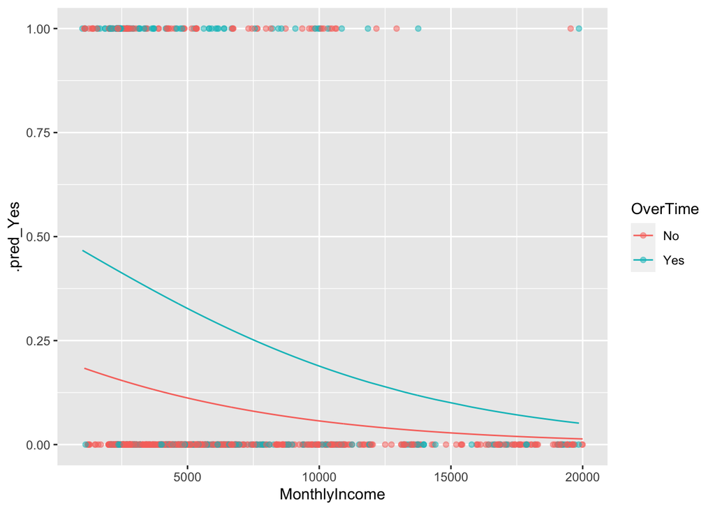

```r
wf_3 %>%
    broom::augment(churn_train) %>%
    mutate(Attrition_prob = if_else(Attrition == "Yes", 1, 0)) %>%
    ggplot(
        aes(MonthlyIncome, .pred_Yes, colour = OverTime)) +
    geom_line() +
    geom_point(
        aes(MonthlyIncome, Attrition_prob, colour = OverTime),
        alpha = 0.5)
```

## Assessing model accuracy

To assess accuracy of our model without touching the test data set, we’ll create some resamples and measure performance on those.

```r
churn_resamples <- rsample::vfold_cv(
    data = churn_train,
    v = 10)

wf_rs_1 <- wf_1 %>%
    tune::fit_resamples(
        resamples = churn_resamples,
        control = tune::control_resamples(save_pred = TRUE))

wf_rs_2 <- wf_2 %>%
    tune::fit_resamples(
        resamples = churn_resamples,
        control = tune::control_resamples(save_pred = TRUE))

wf_rs_3 <- wf_3 %>%
    tune::fit_resamples(
        resamples = churn_resamples,
        control = tune::control_resamples(save_pred = TRUE))

form_4 <- Attrition ~ .

wf_rs_4 <- workflows::workflow() %>%
    workflows::add_formula(form_4) %>%
    workflows::add_model(model_base) %>%
    tune::fit_resamples(
        resamples = churn_resamples,
        control = tune::control_resamples(save_pred = TRUE))
```

We can now compare the models.

```r
wf_rs_1 %>%
    tune::collect_predictions() %>%
    yardstick::conf_mat(
        Attrition,
        .pred_class)
```

```
##           Truth
## Prediction  No Yes
##        No  863 165
##        Yes   0   0
```

```r
wf_rs_2 %>%
    tune::collect_predictions() %>%
    yardstick::conf_mat(
        Attrition,
        .pred_class)
```

```
##           Truth
## Prediction  No Yes
##        No  863 165
##        Yes   0   0
```

```r
wf_rs_3 %>%
    tune::collect_predictions() %>%
    yardstick::conf_mat(
        Attrition,
        .pred_class)
```

```
##           Truth
## Prediction  No Yes
##        No  863 165
##        Yes   0   0
```

```r
wf_rs_4 %>%
    tune::collect_predictions() %>%
    yardstick::conf_mat(
        Attrition,
        .pred_class)
```

```
##           Truth
## Prediction  No Yes
##        No  828  97
##        Yes  35  68
```

The only model of these that considers classifying an outcome as a Yes is the last one that used every possible feature. Let’s see the ROC curve for this model.

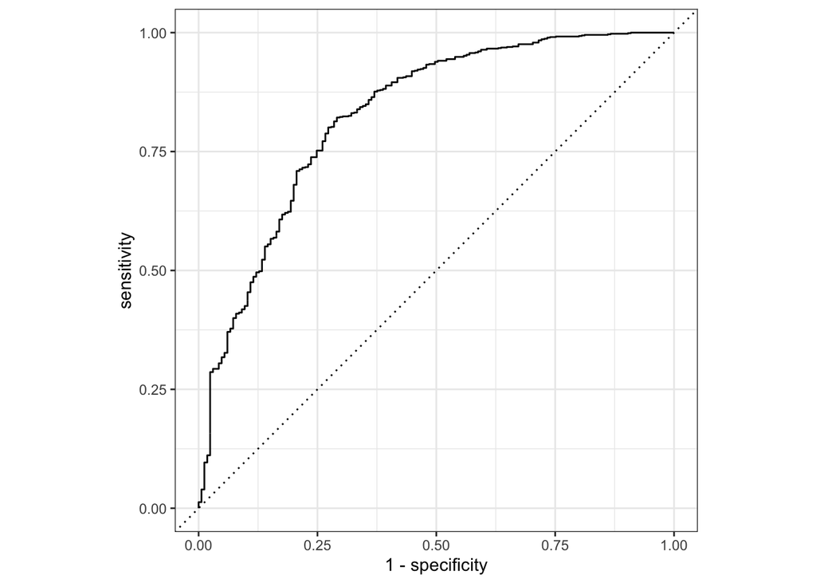

```r
wf_rs_4 %>%
    tune::collect_predictions() %>%
    yardstick::roc_curve(Attrition, .pred_No) %>%
    autoplot()
```

## Feature interpretation

Let’s do the final fit of our model

```r
wf_final <- workflows::workflow() %>%
    workflows::add_formula(form_4) %>%
    workflows::add_model(model_base) %>%
    tune::last_fit(
        churn_split)
```

Finally let’s use the `vip` package to extract the most significant features in the model according to their coefficients.

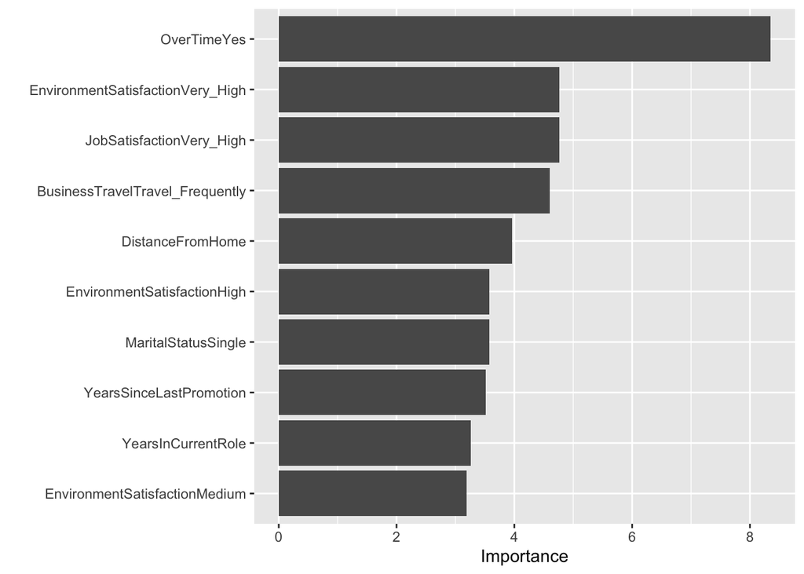

```r
vip::vip(
    wf_final %>%
        workflows::extract_fit_engine())
```